# Artificial Ecosystem Selection Update

Andrew Morris

10/21/2020

## What I’m hoping to get out of this

- Practice talking about why I’m doing what I’m doing and what we can learn from it.
- Hear your questions and comments that might guide future steps.
- Talk about what “heritability” means in a community context.

# How does biodiversity influence ecosystem function?

## One approach

Relating alpha diversity within a functional group to the *rate* or *stability* of an ecosystem function

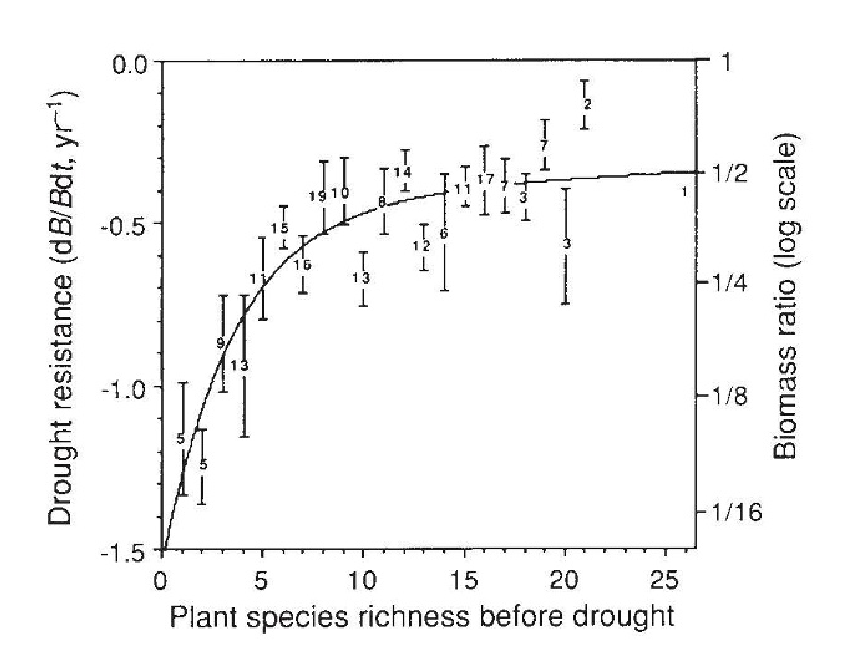

## Reasons this works

1. There’s a clear unit of biological organization - the species.
2. It’s obvious what a “plant” is.
3. Communities are relatively simple (1-25 species).

## Limitations of microbial community data

1. No consistent species concept.
2. What’s a plant?
3. Diversity can be 100s to 10,000s.

## An alternative conceptualization of communities

A community is a pool of genes analogous to a genome (the metagenome) and that community exhibits a phenotype (ecosystem function).

Thinking about it this way, an ecosystem function might exhibit similar properties to an organismal trait.

$V_P = V_G + V_E$

## Heritability is “the relative importance of heredity in determining phenotypic values”

“A character can be ‘hereditary’ in the sense of being **determined by the genotype**[1] or in the sense of being **transmitted from parents to offspring**[2].”

[1] Broad-sense heritability, $H^2 = V_G / V_P$

[2] Narrow-sense heritability, $h^2 = V_A / V_P$

Falconer and MacKay, 1996

# An alternative approach to linking microbial communities to ecosystem function

## Artificial Ecosystem Selection

1. Generate lots of communities with different combinations of taxa.
2. Put them into a common environment to minimize environmental variation.
3. Test which combinations generate the greatest function.
4. Reshuffle the best communities and test again.
5. Investigate which taxa respond to selection.

## Design

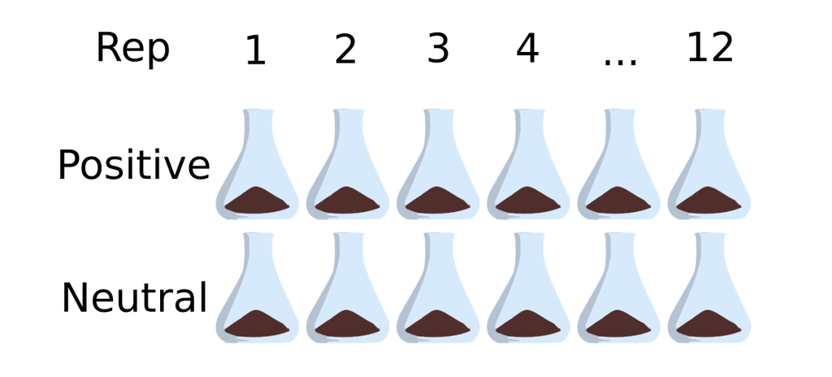

# Is there a response to selection at the ecosystem level on soil methane oxidation rate?

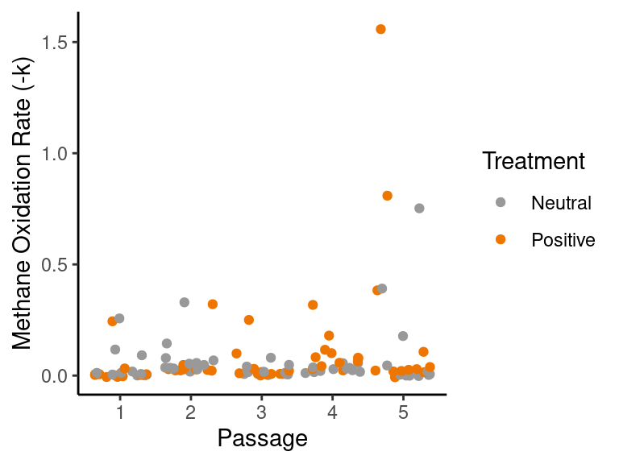

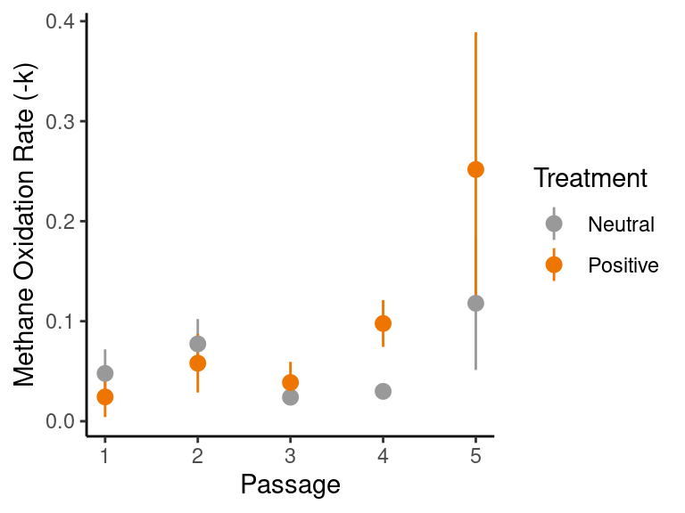

## Community composition impacts the rate of this ecosystem function

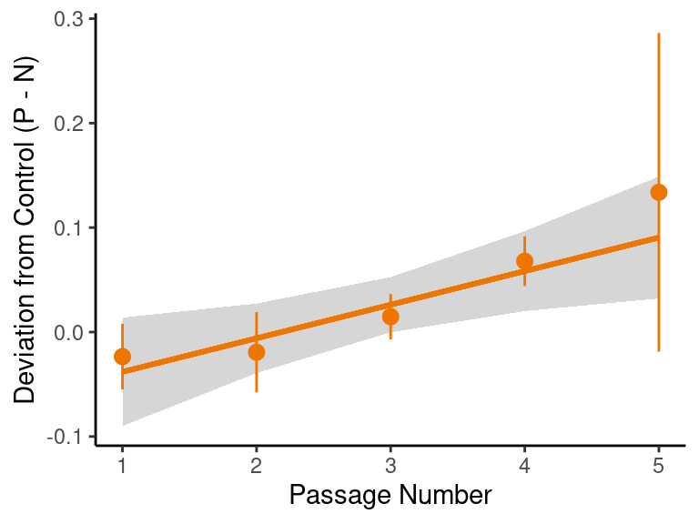

There was a response to selection on soil methane oxidation rate in the positive treatment relative to the neutral treatment.

z = 2.60, p = 0.009

slope = 0.032 $\pm$ 0.012

(initial mean flux = 0.036 $\pm$ 0.015)

# How *heritable* is soil methane oxidation rate as an ecosystem trait?

## Broad- vs. Narrow-sense heritability

$V_G/V_P$ is the extent to which phenotype is determined by the genotype.

$V_A/V_P$ is the extent to which phenotype is determined by the genes transmitted from the parents.

## Broad- vs. Narrow-sense heritability

$V_G/V_P$ is the extent to which phenotype is determined by the genotype.

**$V_A/V_P$ is the extent to which phenotype is determined by the genes transmitted from the parents.**

## Narrow-sense heritability

$h^2 = R / S$

$R$ = Response to selection, difference between parents and offspring

$S$ = Selection differential, difference between selected parents and all parents

## Half of the variation in methane oxidation rate is attributable to the additive effect of genes passed from the parents

Positive: 0.52 $\pm$ 0.09

Neutral: -0.21 $\pm$ 1.66

The remainder is due to environmental variation not controlled for experimentally or with the neutral treatment, interactions among taxa, …?

Caveat: $h^2$ may be affected by correlated traits also under selection.

## Heritability for the positive and neutral lines

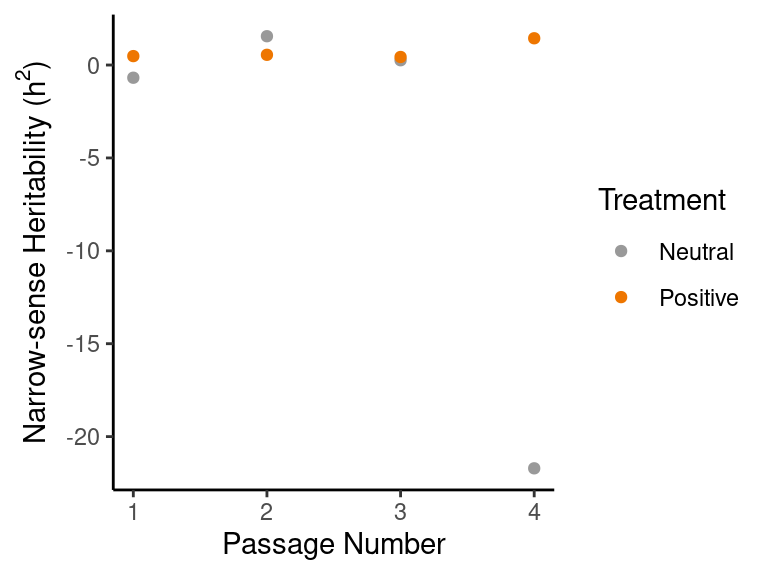

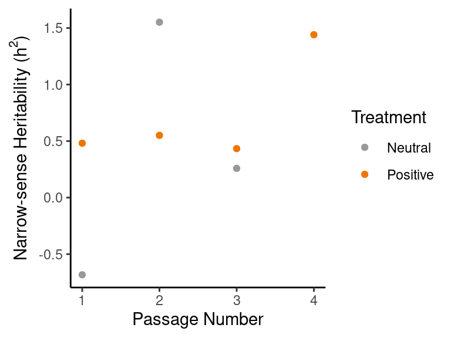

# Which taxa respond to selection? Are correlated with flux?

## In progress:

- Sequencing *pmoA* to characterize the diversity of methane oxidizers.
- Sequencing 16S to look broadly at bacterial/archaeal taxa.